# Forest change in the Dominican Republic, 2000-2016

John D. Lloyd and Yolanda M. Leon

5/25/2018

# Introduction

The United Nations (UN) 2030 Agenda for Sustainable Development proposes a vision of a “world free of poverty, hunger, disease and want, where all life can thrive” (United Nations General Assembly, 2015, p. 1). At the heart of the agenda are the 17 Sustainable Development Goals (SDG), which were formally announced in 2016 and which address the world’s most pressing economic, social, and environmental problems. Crafting effective policy interventions to acheive these goals requires ongoing assessments of progress; doing so can reveal which interventions work and which do not. Monitoring can also help galvanize action if, for example, it reveals significant successes or shortcomings. Evaluating progress towards the SDG is also extremely challenging: it requires timely, highly resolved data at a global scale for each of the 169 indicators underlying the SDG. For many of the indicators, it also requires an adequate historical baseline. For example, a key indicator of progress for SDG 15, focused on conservation of terrestrial ecosystems, is change in the rate of deforestation.

As with implementation of the 2030 Agenda in general, evaluation of progress depends on a global partnership. No single organization or agency can effectively generate, store, and analyze the disaggregated data needed to address the indicators of success. Here, we provide a contribution to this partnership by reporting on the state of forests in the Dominican Republic (DR) during the decades prior to the implementation of the SDG. These data, covering the period 2000-2016, provide a historical baseline against which success in acheiving the SDG may be measured. In particular we address targets 15.1, 15.2, and 15.4, and the associated indicators 15.1.1, 15.1.2, 15.2.1, and 15.4.1. (United Nations General Assembly, 2017). These data also offer insight into another key international agreement on conservation, the Convention on Biological Diversity’s Strategic Plan for Biodiversity 2011-2020, notably Aichi Targets 5 - to reduce the rate of deforestation by at least 50% by 2020 - and 11, which sets a goal of protecting at least 17% of the Earth’s land, especially areas that support high biodiversity and generate important ecosystem services.

The DR serves as a useful case study for at least two reasons. First, it supports an outstanding number of endemic species (Myers et al., 2000), many of which are threatened with extinction (Ministerio de Medio Ambiente y Recursos Naturales de la República Dominicana, 2011). Second, as a middle-income country, the DR is broadly reflective of the challenges of sustainable development faced by most of the world. In quantifying recent changes in the extent of different forest ecosystems in the DR, as well as the distribution and efficacy of protected areas in the country, we hope to facilitate future efforts to document progress towards key conservation and sustainable-development goals, to identify both forest types at greatest risk and spatial hotspots of deforestation, and to suggest fruitful areas for investment of conservation resources.

# Methods

## Quantifying forest change

We estimated annual changes in forest cover between 2000 and 2016 using version 1.4 of the Hansen et al. (2013) data, accessed through the Google Earth Engine (http://earthenginepartners.appspot.com/science-2013-global-forest). We used the per-pixel estimate of forest cover in 2000 as our baseline such that our estimates of the area of forest lost or gained are corrected for initial conditions. For example, a pixel (30m<sup>2</sup>) deforested between 2000 and 2016 that was estimated to have had 25% forest cover in 2000 was calculated as a loss of 225 m<sup>2</sup> (i.e., total pixel area multiplied by the percent of forest cover in 2000). We generated separate estimates of change for each forest type identified in a raster of land-cover types produced by the environment ministry (Ministerio Medio Ambiente y Recursos Naturales [MARENA]) in 1996, which provides the only pre-2000 estimate of land-cover types across the country.

## Separating wildfire from other causes of forest loss

Fire can be a significant driver of vegetation dynamics in the DR, especially in montane forests (Sherman et al., 2008), so to examine the role of wildfire as an agent of forest loss we used the monthly, MODIS-based estimates of the area burned from Giglio et al. (2015) . To do so, we assumed that forest loss was caused by fire for any pixel in the Hansen et al. (2013) data that was within the boundaries of a burned area and was estimated as having been deforested in that year. Our estimates of forest lost to wildlife are likely exaggerated because area burned was estimated at a larger spatial scale than forest change (500m<sup>2</sup> and 30m<sup>2</sup>, respectively). Variation in temporal resolution - area burned is estimated on a monthly basis, whereas forest loss and gain is estimated annually based on LANDSAT images during the growing season - may also contributes to error in our annual estimates of forest-area burned, although this source of error should be insignificant over the course of the entire study.

## Quantifying forest change within protected areas

To examine whether forest within formally protected areas showed different patterns of forest change, we calculated forest gain, forest loss, and area burned for each protected area within the DR, using a shapefile of protected-area boundaries provided by MARENA.

# Results

## Quantifying forest change

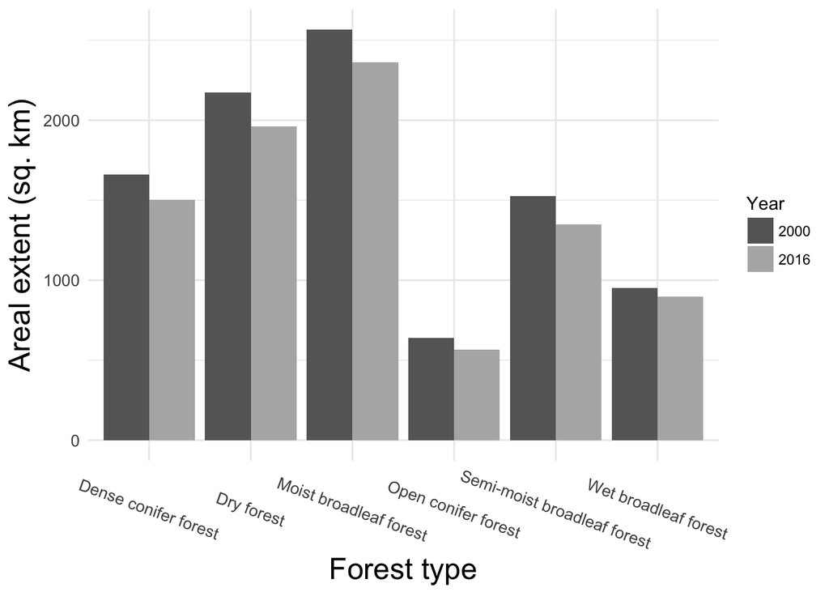

Figure 1. Change in the areal extent of different forest types in the Dominican Republic, 2000-2016

# Literature Cited

Giglio, L., Justice, C., Boschetti, L., Roy, D., 2015. MCD64A1 MODIS/Terra+Aqua Burned Area Monthly L3 Global 500m SIN Grid V006 [Data set]. https://doi.org/10.5067/MODIS/MCD64A1.006

Hansen, M.C., Potapov, P.V., Moore, R., Hancher, M., Turubanova, S., Tyukavina, A., Thau, D., Stehman, S., Goetz, S., Loveland, T., Kommareddy, A., Egorov, A., Chini, L., Justice, C., Townshed, J., 2013. High-resolution global maps of 21st-century forest cover change. Science 342, 850–853.

Ministerio de Medio Ambiente y Recursos Naturales de la República Dominicana, 2011. Lista de especies en peligro ed extinctión, amenazadas o protegidas de la República Dominicana (Lista Roja).

Myers, N., Mittermeier, R.A., Mittermeier, C.G., Da Fonseca, G.A., Kent, J., 2000. Biodiversity hotspots for conservation priorities. Nature 403, 853–858.

Sherman, R.E., Martin, P.H., Fahey, T.J., Degloria, S.D., 2008. Fire and vegetation dynamics in high-elevation neotropical montane forests of the dominican republic. AMBIO: A Journal of the Human Environment 37, 535–541.

United Nations General Assembly, 2017. Work of the Statistical Commission pertaining to the 2030 Agenda for Sustainable Development, A/RES/71/313.

United Nations General Assembly, 2015. Transforming our world: the 2030 Agenda for Sustainable Development, A/RES/70/L.1.